# Risk Factor Analysis

## Outcome Variable

**Outcome Variable:** wast_rec90d

## Predictor Variables

**Intervention Variable:** impsan

**Adjustment Set:**

- arm
- sex
- W_mage
- meducyrs
- feducyrs
- hhwealth_quart
- hfoodsec
- W_mhtcm
- W_mwtkg
- W_mbmi
- W_nrooms
- W_nchldlt5
- W_parity
- impfloor
- safeh20
- delta_W_mage
- delta_meducyrs
- delta_feducyrs
- delta_hhwealth_quart
- delta_hfoodsec
- delta_W_mhtcm
- delta_W_mwtkg
- delta_W_mbmi
- delta_W_nrooms
- delta_W_nchldlt5
- delta_W_parity
- delta_impfloor
- delta_safeh20

## Stratifying Variables

The analysis was stratified on these variable(s):

- agecat
- studyid
- country

## Data Summary

| agecat | studyid | country | impsan | wast_rec90d | n_cell | n |
| --- | --- | --- | --- | --- | --- | --- |
| 0-24 months | COHORTS | GUATEMALA | 1 | 0 | 10 | 264 |
| 0-24 months | COHORTS | GUATEMALA | 1 | 1 | 14 | 264 |
| 0-24 months | COHORTS | GUATEMALA | 0 | 0 | 154 | 264 |
| 0-24 months | COHORTS | GUATEMALA | 0 | 1 | 86 | 264 |
| 0-24 months | COHORTS | INDIA | 1 | 0 | 452 | 1962 |
| 0-24 months | COHORTS | INDIA | 1 | 1 | 178 | 1962 |
| 0-24 months | COHORTS | INDIA | 0 | 0 | 1050 | 1962 |
| 0-24 months | COHORTS | INDIA | 0 | 1 | 282 | 1962 |
| 0-24 months | COHORTS | PHILIPPINES | 1 | 0 | 22 | 683 |
| 0-24 months | COHORTS | PHILIPPINES | 1 | 1 | 58 | 683 |
| 0-24 months | COHORTS | PHILIPPINES | 0 | 0 | 242 | 683 |
| 0-24 months | COHORTS | PHILIPPINES | 0 | 1 | 361 | 683 |
| 0-24 months | CONTENT | PERU | 1 | 0 | 1 | 7 |
| 0-24 months | CONTENT | PERU | 1 | 1 | 6 | 7 |
| 0-24 months | CONTENT | PERU | 0 | 0 | 0 | 7 |
| 0-24 months | CONTENT | PERU | 0 | 1 | 0 | 7 |
| 0-24 months | JiVitA-3 | BANGLADESH | 1 | 0 | 2903 | 7560 |
| 0-24 months | JiVitA-3 | BANGLADESH | 1 | 1 | 2228 | 7560 |
| 0-24 months | JiVitA-3 | BANGLADESH | 0 | 0 | 1463 | 7560 |
| 0-24 months | JiVitA-3 | BANGLADESH | 0 | 1 | 966 | 7560 |
| 0-24 months | JiVitA-4 | BANGLADESH | 1 | 0 | 1115 | 2062 |
| 0-24 months | JiVitA-4 | BANGLADESH | 1 | 1 | 390 | 2062 |
| 0-24 months | JiVitA-4 | BANGLADESH | 0 | 0 | 415 | 2062 |
| 0-24 months | JiVitA-4 | BANGLADESH | 0 | 1 | 142 | 2062 |
| 0-24 months | LCNI-5 | MALAWI | 1 | 0 | 0 | 77 |
| 0-24 months | LCNI-5 | MALAWI | 1 | 1 | 0 | 77 |
| 0-24 months | LCNI-5 | MALAWI | 0 | 0 | 65 | 77 |
| 0-24 months | LCNI-5 | MALAWI | 0 | 1 | 12 | 77 |
| 0-24 months | MAL-ED | BANGLADESH | 1 | 0 | 33 | 121 |
| 0-24 months | MAL-ED | BANGLADESH | 1 | 1 | 67 | 121 |

[output cut: 174 more lines]

The following strata were considered:

- agecat: 0-24 months, studyid: COHORTS, country: GUATEMALA
- agecat: 0-24 months, studyid: COHORTS, country: INDIA
- agecat: 0-24 months, studyid: COHORTS, country: PHILIPPINES
- agecat: 0-24 months, studyid: CONTENT, country: PERU
- agecat: 0-24 months, studyid: JiVitA-3, country: BANGLADESH
- agecat: 0-24 months, studyid: JiVitA-4, country: BANGLADESH
- agecat: 0-24 months, studyid: LCNI-5, country: MALAWI
- agecat: 0-24 months, studyid: MAL-ED, country: BANGLADESH
- agecat: 0-24 months, studyid: MAL-ED, country: BRAZIL
- agecat: 0-24 months, studyid: MAL-ED, country: INDIA
- agecat: 0-24 months, studyid: MAL-ED, country: NEPAL
- agecat: 0-24 months, studyid: MAL-ED, country: PERU
- agecat: 0-24 months, studyid: MAL-ED, country: SOUTH AFRICA
- agecat: 0-24 months, studyid: MAL-ED, country: TANZANIA, UNITED REPUBLIC OF
- agecat: 0-24 months, studyid: NIH-Birth, country: BANGLADESH
- agecat: 0-24 months, studyid: NIH-Crypto, country: BANGLADESH
- agecat: 0-24 months, studyid: PROVIDE, country: BANGLADESH
- agecat: 0-6 months, studyid: COHORTS, country: GUATEMALA
- agecat: 0-6 months, studyid: COHORTS, country: INDIA
- agecat: 0-6 months, studyid: COHORTS, country: PHILIPPINES
- agecat: 0-6 months, studyid: CONTENT, country: PERU
- agecat: 0-6 months, studyid: JiVitA-3, country: BANGLADESH
- agecat: 0-6 months, studyid: JiVitA-4, country: BANGLADESH
- agecat: 0-6 months, studyid: LCNI-5, country: MALAWI
- agecat: 0-6 months, studyid: MAL-ED, country: BANGLADESH
- agecat: 0-6 months, studyid: MAL-ED, country: BRAZIL
- agecat: 0-6 months, studyid: MAL-ED, country: INDIA
- agecat: 0-6 months, studyid: MAL-ED, country: NEPAL
- agecat: 0-6 months, studyid: MAL-ED, country: PERU
- agecat: 0-6 months, studyid: MAL-ED, country: SOUTH AFRICA
- agecat: 0-6 months, studyid: MAL-ED, country: TANZANIA, UNITED REPUBLIC OF
- agecat: 0-6 months, studyid: NIH-Birth, country: BANGLADESH
- agecat: 0-6 months, studyid: NIH-Crypto, country: BANGLADESH
- agecat: 0-6 months, studyid: PROVIDE, country: BANGLADESH
- agecat: 6-24 months, studyid: COHORTS, country: GUATEMALA
- agecat: 6-24 months, studyid: COHORTS, country: INDIA
- agecat: 6-24 months, studyid: COHORTS, country: PHILIPPINES
- agecat: 6-24 months, studyid: CONTENT, country: PERU
- agecat: 6-24 months, studyid: JiVitA-3, country: BANGLADESH
- agecat: 6-24 months, studyid: JiVitA-4, country: BANGLADESH
- agecat: 6-24 months, studyid: LCNI-5, country: MALAWI
- agecat: 6-24 months, studyid: MAL-ED, country: BANGLADESH
- agecat: 6-24 months, studyid: MAL-ED, country: BRAZIL
- agecat: 6-24 months, studyid: MAL-ED, country: INDIA
- agecat: 6-24 months, studyid: MAL-ED, country: NEPAL
- agecat: 6-24 months, studyid: MAL-ED, country: PERU
- agecat: 6-24 months, studyid: MAL-ED, country: SOUTH AFRICA
- agecat: 6-24 months, studyid: MAL-ED, country: TANZANIA, UNITED REPUBLIC OF
- agecat: 6-24 months, studyid: NIH-Birth, country: BANGLADESH
- agecat: 6-24 months, studyid: NIH-Crypto, country: BANGLADESH
- agecat: 6-24 months, studyid: PROVIDE, country: BANGLADESH

### Dropped Strata

Some strata were dropped due to rare outcomes:

- agecat: 0-24 months, studyid: CONTENT, country: PERU
- agecat: 0-24 months, studyid: LCNI-5, country: MALAWI
- agecat: 0-24 months, studyid: MAL-ED, country: BRAZIL
- agecat: 0-24 months, studyid: MAL-ED, country: NEPAL
- agecat: 0-24 months, studyid: MAL-ED, country: PERU
- agecat: 0-24 months, studyid: MAL-ED, country: SOUTH AFRICA
- agecat: 0-24 months, studyid: MAL-ED, country: TANZANIA, UNITED REPUBLIC OF
- agecat: 0-24 months, studyid: PROVIDE, country: BANGLADESH
- agecat: 0-6 months, studyid: COHORTS, country: GUATEMALA
- agecat: 0-6 months, studyid: CONTENT, country: PERU
- agecat: 0-6 months, studyid: LCNI-5, country: MALAWI
- agecat: 0-6 months, studyid: MAL-ED, country: BANGLADESH
- agecat: 0-6 months, studyid: MAL-ED, country: BRAZIL
- agecat: 0-6 months, studyid: MAL-ED, country: NEPAL
- agecat: 0-6 months, studyid: MAL-ED, country: PERU
- agecat: 0-6 months, studyid: MAL-ED, country: SOUTH AFRICA
- agecat: 0-6 months, studyid: MAL-ED, country: TANZANIA, UNITED REPUBLIC OF
- agecat: 0-6 months, studyid: NIH-Crypto, country: BANGLADESH
- agecat: 0-6 months, studyid: PROVIDE, country: BANGLADESH
- agecat: 6-24 months, studyid: COHORTS, country: GUATEMALA
- agecat: 6-24 months, studyid: COHORTS, country: INDIA
- agecat: 6-24 months, studyid: CONTENT, country: PERU
- agecat: 6-24 months, studyid: JiVitA-3, country: BANGLADESH
- agecat: 6-24 months, studyid: LCNI-5, country: MALAWI
- agecat: 6-24 months, studyid: MAL-ED, country: BANGLADESH
- agecat: 6-24 months, studyid: MAL-ED, country: BRAZIL
- agecat: 6-24 months, studyid: MAL-ED, country: NEPAL
- agecat: 6-24 months, studyid: MAL-ED, country: PERU
- agecat: 6-24 months, studyid: MAL-ED, country: SOUTH AFRICA
- agecat: 6-24 months, studyid: MAL-ED, country: TANZANIA, UNITED REPUBLIC OF
- agecat: 6-24 months, studyid: NIH-Crypto, country: BANGLADESH
- agecat: 6-24 months, studyid: PROVIDE, country: BANGLADESH

## Methods Detail

We’re interested in the causal parameters $E[Y_a]$ for all values of $a \in \mathcal{A}$. These parameters represent the mean outcome if, possibly contrary to fact, we intervened to set all units to have $A=a$. Under the randomization and positivity assumptions, these are identified by the statistical parameters $\psi_a=E_W[E_{Y|A,W}(Y|A=a,W)]$. In addition, we’re interested in the mean of $Y$, $E[Y]$ under no intervention (the observed mean). We will estimate these parameters by using SuperLearner to fit the relevant likelihood factors – $E_{Y|A,W}(Y|A=a,W)$ and $p(A=a|W)$, and then updating our likelihood fit using a joint TMLE.

For unadjusted analyses ($W=\{\}$), initial likelihoods were estimated using Lrnr_glm to estimate the simple $E(Y|A)$ and Lrnr_mean to estimate $p(A)$. For adjusted analyses, a small library containing Lrnr_glmnet, Lrnr_xgboost, and Lrnr_mean was used.

Having estimated these parameters, we will then use the delta method to estimate relative risks and attributable risks relative to a prespecified baseline level of $A$.

# Results Detail

## Results Plots

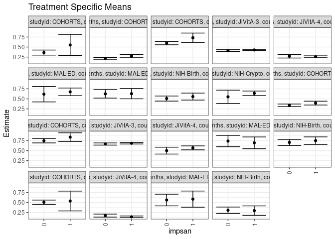

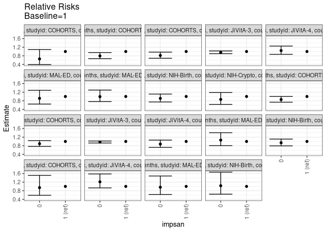

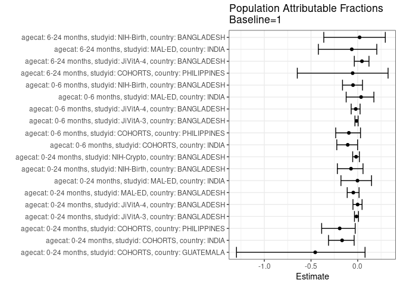

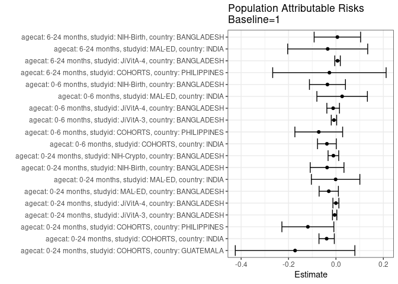

## Results Table

### Parameter: TSM

| agecat | studyid | country | intervention_level | baseline_level | estimate | ci_lower | ci_upper |
| --- | --- | --- | --- | --- | --- | --- | --- |
| 0-24 months | COHORTS | GUATEMALA | 1 | NA | 0.5511773 | 0.2878121 | 0.8145425 |
| 0-24 months | COHORTS | GUATEMALA | 0 | NA | 0.3621886 | 0.2991975 | 0.4251797 |
| 0-24 months | COHORTS | INDIA | 1 | NA | 0.2736646 | 0.2343233 | 0.3130058 |
| 0-24 months | COHORTS | INDIA | 0 | NA | 0.2181238 | 0.1956156 | 0.2406320 |
| 0-24 months | COHORTS | PHILIPPINES | 1 | NA | 0.7318640 | 0.6151529 | 0.8485751 |
| 0-24 months | COHORTS | PHILIPPINES | 0 | NA | 0.5979340 | 0.5574488 | 0.6384191 |
| 0-24 months | JiVitA-3 | BANGLADESH | 1 | NA | 0.4278786 | 0.4132078 | 0.4425493 |
| 0-24 months | JiVitA-3 | BANGLADESH | 0 | NA | 0.4110076 | 0.3875029 | 0.4345123 |
| 0-24 months | JiVitA-4 | BANGLADESH | 1 | NA | 0.2582153 | 0.2347220 | 0.2817086 |
| 0-24 months | JiVitA-4 | BANGLADESH | 0 | NA | 0.2692740 | 0.2266671 | 0.3118809 |
| 0-24 months | MAL-ED | BANGLADESH | 1 | NA | 0.6749116 | 0.5791755 | 0.7706476 |
| 0-24 months | MAL-ED | BANGLADESH | 0 | NA | 0.6165538 | 0.4241916 | 0.8089161 |
| 0-24 months | MAL-ED | INDIA | 1 | NA | 0.6293134 | 0.5013453 | 0.7572815 |
| 0-24 months | MAL-ED | INDIA | 0 | NA | 0.6252907 | 0.5196511 | 0.7309303 |
| 0-24 months | NIH-Birth | BANGLADESH | 1 | NA | 0.5574819 | 0.4701363 | 0.6448276 |
| 0-24 months | NIH-Birth | BANGLADESH | 0 | NA | 0.5078893 | 0.4447655 | 0.5710132 |
| 0-24 months | NIH-Crypto | BANGLADESH | 1 | NA | 0.6382102 | 0.5807895 | 0.6956310 |
| 0-24 months | NIH-Crypto | BANGLADESH | 0 | NA | 0.5510227 | 0.3844747 | 0.7175707 |
| 0-6 months | COHORTS | INDIA | 1 | NA | 0.3947092 | 0.3466121 | 0.4428062 |
| 0-6 months | COHORTS | INDIA | 0 | NA | 0.3388788 | 0.3061326 | 0.3716249 |
| 0-6 months | COHORTS | PHILIPPINES | 1 | NA | 0.8367347 | 0.7280039 | 0.9454655 |
| 0-6 months | COHORTS | PHILIPPINES | 0 | NA | 0.7489177 | 0.6935154 | 0.8043201 |
| 0-6 months | JiVitA-3 | BANGLADESH | 1 | NA | 0.6838803 | 0.6663318 | 0.7014288 |
| 0-6 months | JiVitA-3 | BANGLADESH | 0 | NA | 0.6659381 | 0.6388150 | 0.6930612 |
| 0-6 months | JiVitA-4 | BANGLADESH | 1 | NA | 0.5701421 | 0.5206625 | 0.6196217 |
| 0-6 months | JiVitA-4 | BANGLADESH | 0 | NA | 0.5008223 | 0.4151952 | 0.5864495 |
| 0-6 months | MAL-ED | INDIA | 1 | NA | 0.6953879 | 0.5485635 | 0.8422123 |
| 0-6 months | MAL-ED | INDIA | 0 | NA | 0.7395992 | 0.5987985 | 0.8803999 |
| 0-6 months | NIH-Birth | BANGLADESH | 1 | NA | 0.7488462 | 0.6542258 | 0.8434665 |
| 0-6 months | NIH-Birth | BANGLADESH | 0 | NA | 0.7045969 | 0.6278735 | 0.7813203 |
| 6-24 months | COHORTS | PHILIPPINES | 1 | NA | 0.5362259 | 0.2897000 | 0.7827519 |
| 6-24 months | COHORTS | PHILIPPINES | 0 | NA | 0.5059073 | 0.4519047 | 0.5599100 |
| 6-24 months | JiVitA-4 | BANGLADESH | 1 | NA | 0.1424887 | 0.1212682 | 0.1637093 |
| 6-24 months | JiVitA-4 | BANGLADESH | 0 | NA | 0.1729156 | 0.1353690 | 0.2104623 |
| 6-24 months | MAL-ED | INDIA | 1 | NA | 0.5832029 | 0.3814389 | 0.7849668 |
| 6-24 months | MAL-ED | INDIA | 0 | NA | 0.5610665 | 0.4156887 | 0.7064443 |
| 6-24 months | NIH-Birth | BANGLADESH | 1 | NA | 0.2969310 | 0.1791961 | 0.4146660 |
| 6-24 months | NIH-Birth | BANGLADESH | 0 | NA | 0.3065753 | 0.2267953 | 0.3863554 |

### Parameter: E(Y)

| agecat | studyid | country | intervention_level | baseline_level | estimate | ci_lower | ci_upper |
| --- | --- | --- | --- | --- | --- | --- | --- |
| 0-24 months | COHORTS | GUATEMALA | NA | NA | 0.3787879 | 0.3179432 | 0.4396325 |
| 0-24 months | COHORTS | INDIA | NA | NA | 0.2344546 | 0.2156201 | 0.2532892 |
| 0-24 months | COHORTS | PHILIPPINES | NA | NA | 0.6134700 | 0.5751620 | 0.6517779 |
| 0-24 months | JiVitA-3 | BANGLADESH | NA | NA | 0.4224868 | 0.4113573 | 0.4336163 |
| 0-24 months | JiVitA-4 | BANGLADESH | NA | NA | 0.2580019 | 0.2386523 | 0.2773515 |
| 0-24 months | MAL-ED | BANGLADESH | NA | NA | 0.6446281 | 0.5577732 | 0.7314830 |
| 0-24 months | MAL-ED | INDIA | NA | NA | 0.6279070 | 0.5477344 | 0.7080796 |
| 0-24 months | NIH-Birth | BANGLADESH | NA | NA | 0.5201900 | 0.4695846 | 0.5707955 |
| 0-24 months | NIH-Crypto | BANGLADESH | NA | NA | 0.6274510 | 0.5732906 | 0.6816113 |
| 0-6 months | COHORTS | INDIA | NA | NA | 0.3565891 | 0.3304405 | 0.3827378 |
| 0-6 months | COHORTS | PHILIPPINES | NA | NA | 0.7642857 | 0.7146210 | 0.8139505 |
| 0-6 months | JiVitA-3 | BANGLADESH | NA | NA | 0.6755499 | 0.6622049 | 0.6888949 |
| 0-6 months | JiVitA-4 | BANGLADESH | NA | NA | 0.5583942 | 0.5167799 | 0.6000084 |
| 0-6 months | MAL-ED | INDIA | NA | NA | 0.7215190 | 0.6193314 | 0.8237066 |
| 0-6 months | NIH-Birth | BANGLADESH | NA | NA | 0.7130045 | 0.6535890 | 0.7724200 |
| 6-24 months | COHORTS | PHILIPPINES | NA | NA | 0.5086849 | 0.4571562 | 0.5602135 |
| 6-24 months | JiVitA-4 | BANGLADESH | NA | NA | 0.1492734 | 0.1316631 | 0.1668838 |
| 6-24 months | MAL-ED | INDIA | NA | NA | 0.5483871 | 0.4327976 | 0.6639766 |
| 6-24 months | NIH-Birth | BANGLADESH | NA | NA | 0.3030303 | 0.2377927 | 0.3682679 |

### Parameter: RR

| agecat | studyid | country | intervention_level | baseline_level | estimate | ci_lower | ci_upper |
| --- | --- | --- | --- | --- | --- | --- | --- |
| 0-24 months | COHORTS | GUATEMALA | 1 | 1 | 1.0000000 | 1.0000000 | 1.0000000 |
| 0-24 months | COHORTS | GUATEMALA | 0 | 1 | 0.6571181 | 0.3954543 | 1.0919193 |
| 0-24 months | COHORTS | INDIA | 1 | 1 | 1.0000000 | 1.0000000 | 1.0000000 |
| 0-24 months | COHORTS | INDIA | 0 | 1 | 0.7970480 | 0.6678613 | 0.9512237 |
| 0-24 months | COHORTS | PHILIPPINES | 1 | 1 | 1.0000000 | 1.0000000 | 1.0000000 |
| 0-24 months | COHORTS | PHILIPPINES | 0 | 1 | 0.8170015 | 0.6869097 | 0.9717310 |
| 0-24 months | JiVitA-3 | BANGLADESH | 1 | 1 | 1.0000000 | 1.0000000 | 1.0000000 |
| 0-24 months | JiVitA-3 | BANGLADESH | 0 | 1 | 0.9605707 | 0.8989156 | 1.0264545 |
| 0-24 months | JiVitA-4 | BANGLADESH | 1 | 1 | 1.0000000 | 1.0000000 | 1.0000000 |
| 0-24 months | JiVitA-4 | BANGLADESH | 0 | 1 | 1.0428276 | 0.8688796 | 1.2515998 |
| 0-24 months | MAL-ED | BANGLADESH | 1 | 1 | 1.0000000 | 1.0000000 | 1.0000000 |
| 0-24 months | MAL-ED | BANGLADESH | 0 | 1 | 0.9135327 | 0.6477571 | 1.2883564 |
| 0-24 months | MAL-ED | INDIA | 1 | 1 | 1.0000000 | 1.0000000 | 1.0000000 |
| 0-24 months | MAL-ED | INDIA | 0 | 1 | 0.9936079 | 0.7615008 | 1.2964617 |
| 0-24 months | NIH-Birth | BANGLADESH | 1 | 1 | 1.0000000 | 1.0000000 | 1.0000000 |
| 0-24 months | NIH-Birth | BANGLADESH | 0 | 1 | 0.9110418 | 0.7456723 | 1.1130856 |
| 0-24 months | NIH-Crypto | BANGLADESH | 1 | 1 | 1.0000000 | 1.0000000 | 1.0000000 |
| 0-24 months | NIH-Crypto | BANGLADESH | 0 | 1 | 0.8633874 | 0.6299350 | 1.1833567 |
| 0-6 months | COHORTS | INDIA | 1 | 1 | 1.0000000 | 1.0000000 | 1.0000000 |
| 0-6 months | COHORTS | INDIA | 0 | 1 | 0.8585531 | 0.7349873 | 1.0028929 |
| 0-6 months | COHORTS | PHILIPPINES | 1 | 1 | 1.0000000 | 1.0000000 | 1.0000000 |
| 0-6 months | COHORTS | PHILIPPINES | 0 | 1 | 0.8950480 | 0.7707387 | 1.0394068 |
| 0-6 months | JiVitA-3 | BANGLADESH | 1 | 1 | 1.0000000 | 1.0000000 | 1.0000000 |
| 0-6 months | JiVitA-3 | BANGLADESH | 0 | 1 | 0.9737641 | 0.9283280 | 1.0214240 |
| 0-6 months | JiVitA-4 | BANGLADESH | 1 | 1 | 1.0000000 | 1.0000000 | 1.0000000 |
| 0-6 months | JiVitA-4 | BANGLADESH | 0 | 1 | 0.8784167 | 0.7249587 | 1.0643583 |
| 0-6 months | MAL-ED | INDIA | 1 | 1 | 1.0000000 | 1.0000000 | 1.0000000 |
| 0-6 months | MAL-ED | INDIA | 0 | 1 | 1.0635779 | 0.8047944 | 1.4055738 |
| 0-6 months | NIH-Birth | BANGLADESH | 1 | 1 | 1.0000000 | 1.0000000 | 1.0000000 |
| 0-6 months | NIH-Birth | BANGLADESH | 0 | 1 | 0.9409101 | 0.7959995 | 1.1122014 |
| 6-24 months | COHORTS | PHILIPPINES | 1 | 1 | 1.0000000 | 1.0000000 | 1.0000000 |
| 6-24 months | COHORTS | PHILIPPINES | 0 | 1 | 0.9434593 | 0.5883563 | 1.5128851 |
| 6-24 months | JiVitA-4 | BANGLADESH | 1 | 1 | 1.0000000 | 1.0000000 | 1.0000000 |
| 6-24 months | JiVitA-4 | BANGLADESH | 0 | 1 | 1.2135388 | 0.9326004 | 1.5791078 |
| 6-24 months | MAL-ED | INDIA | 1 | 1 | 1.0000000 | 1.0000000 | 1.0000000 |
| 6-24 months | MAL-ED | INDIA | 0 | 1 | 0.9620435 | 0.6242315 | 1.4826672 |
| 6-24 months | NIH-Birth | BANGLADESH | 1 | 1 | 1.0000000 | 1.0000000 | 1.0000000 |
| 6-24 months | NIH-Birth | BANGLADESH | 0 | 1 | 1.0324799 | 0.6418911 | 1.6607408 |

### Parameter: PAR

| agecat | studyid | country | intervention_level | baseline_level | estimate | ci_lower | ci_upper |
| --- | --- | --- | --- | --- | --- | --- | --- |
| 0-24 months | COHORTS | GUATEMALA | 1 | NA | -0.1723894 | -0.4246236 | 0.0798448 |
| 0-24 months | COHORTS | INDIA | 1 | NA | -0.0392100 | -0.0715498 | -0.0068701 |
| 0-24 months | COHORTS | PHILIPPINES | 1 | NA | -0.1183940 | -0.2280036 | -0.0087844 |
| 0-24 months | JiVitA-3 | BANGLADESH | 1 | NA | -0.0053918 | -0.0145646 | 0.0037810 |
| 0-24 months | JiVitA-4 | BANGLADESH | 1 | NA | -0.0002133 | -0.0128042 | 0.0123775 |
| 0-24 months | MAL-ED | BANGLADESH | 1 | NA | -0.0302835 | -0.0709325 | 0.0103656 |
| 0-24 months | MAL-ED | INDIA | 1 | NA | -0.0014064 | -0.1037332 | 0.1009204 |
| 0-24 months | NIH-Birth | BANGLADESH | 1 | NA | -0.0372919 | -0.1084815 | 0.0338977 |
| 0-24 months | NIH-Crypto | BANGLADESH | 1 | NA | -0.0107593 | -0.0331960 | 0.0116774 |
| 0-6 months | COHORTS | INDIA | 1 | NA | -0.0381200 | -0.0777546 | 0.0015146 |
| 0-6 months | COHORTS | PHILIPPINES | 1 | NA | -0.0724490 | -0.1732018 | 0.0283039 |
| 0-6 months | JiVitA-3 | BANGLADESH | 1 | NA | -0.0083304 | -0.0197478 | 0.0030870 |
| 0-6 months | JiVitA-4 | BANGLADESH | 1 | NA | -0.0117480 | -0.0383546 | 0.0148587 |
| 0-6 months | MAL-ED | INDIA | 1 | NA | 0.0261311 | -0.0804843 | 0.1327465 |
| 0-6 months | NIH-Birth | BANGLADESH | 1 | NA | -0.0358417 | -0.1117898 | 0.0401065 |
| 6-24 months | COHORTS | PHILIPPINES | 1 | NA | -0.0275411 | -0.2668217 | 0.2117396 |
| 6-24 months | JiVitA-4 | BANGLADESH | 1 | NA | 0.0067847 | -0.0049039 | 0.0184733 |
| 6-24 months | MAL-ED | INDIA | 1 | NA | -0.0348158 | -0.2035974 | 0.1339659 |
| 6-24 months | NIH-Birth | BANGLADESH | 1 | NA | 0.0060993 | -0.0919397 | 0.1041382 |

### Parameter: PAF

| agecat | studyid | country | intervention_level | baseline_level | estimate | ci_lower | ci_upper |
| --- | --- | --- | --- | --- | --- | --- | --- |
| 0-24 months | COHORTS | GUATEMALA | 1 | NA | -0.4551080 | -1.2982119 | 0.0787015 |
| 0-24 months | COHORTS | INDIA | 1 | NA | -0.1672390 | -0.3125633 | -0.0380046 |
| 0-24 months | COHORTS | PHILIPPINES | 1 | NA | -0.1929907 | -0.3859746 | -0.0268780 |
| 0-24 months | JiVitA-3 | BANGLADESH | 1 | NA | -0.0127620 | -0.0346984 | 0.0087093 |
| 0-24 months | JiVitA-4 | BANGLADESH | 1 | NA | -0.0008268 | -0.0508351 | 0.0468015 |
| 0-24 months | MAL-ED | BANGLADESH | 1 | NA | -0.0469782 | -0.1123397 | 0.0145427 |
| 0-24 months | MAL-ED | INDIA | 1 | NA | -0.0022398 | -0.1792131 | 0.1481737 |
| 0-24 months | NIH-Birth | BANGLADESH | 1 | NA | -0.0716890 | -0.2178656 | 0.0569424 |
| 0-24 months | NIH-Crypto | BANGLADESH | 1 | NA | -0.0171476 | -0.0536617 | 0.0181012 |
| 0-6 months | COHORTS | INDIA | 1 | NA | -0.1069018 | -0.2238832 | -0.0011016 |
| 0-6 months | COHORTS | PHILIPPINES | 1 | NA | -0.0947931 | -0.2355973 | 0.0299657 |
| 0-6 months | JiVitA-3 | BANGLADESH | 1 | NA | -0.0123313 | -0.0293762 | 0.0044314 |
| 0-6 months | JiVitA-4 | BANGLADESH | 1 | NA | -0.0210388 | -0.0698373 | 0.0255338 |
| 0-6 months | MAL-ED | INDIA | 1 | NA | 0.0362168 | -0.1235124 | 0.1732374 |
| 0-6 months | NIH-Birth | BANGLADESH | 1 | NA | -0.0502685 | -0.1626442 | 0.0512454 |
| 6-24 months | COHORTS | PHILIPPINES | 1 | NA | -0.0541417 | -0.6467535 | 0.3252088 |
| 6-24 months | JiVitA-4 | BANGLADESH | 1 | NA | 0.0454515 | -0.0364022 | 0.1208405 |
| 6-24 months | MAL-ED | INDIA | 1 | NA | -0.0634876 | -0.4213380 | 0.2042668 |
| 6-24 months | NIH-Birth | BANGLADESH | 1 | NA | 0.0201275 | -0.3632463 | 0.2956885 |